# M2.855_20222_PEC1-Eduardo_Mora_Gonzalez

[figure not shown]

M2.855 · Modelos avanzados de minería de datos · PEC1

2022-2 · Máster universitario en Ciencia de datos (Data science)

Estudios de Informática, Multimedia y Telecomunicación

# PEC 1: Preparación de datos

A lo largo de esta práctica veremos cómo aplicar diferentes técnicas para la carga y preparación de datos:

1. Carga de un conjunto de datos
2. Análisis de los datos  
   2.1 Análisis estadístico básico  
   2.2 Análisis exploratorio de los datos
3. Preprocesado de los datos
4. Reducción de la dimensionalidad
5. Entrenamiento y test

**Importante:** Cada uno de los ejercicios puede suponer varios minutos de ejecución, por lo que la entrega debe hacerse en formato notebook y en formato html, donde se vea el código, los resultados y comentarios de cada ejercicio. Se puede exportar el notebook a html desde el menú File $\to$ Download as $\to$ HTML.

**Importante:** Existe un tipo de celda especial para albergar texto. Este tipo de celda os será muy útil para responder a las diferentes preguntas teóricas planteadas a lo largo de cada PEC. Para cambiar el tipo de celda a este tipo, elegid en el menú: Cell $\to$ Cell Type $\to$ Markdown.

**Importante:** La solución planteada no debe utilizar métodos, funciones o parámetros declarados "deprecated" en futuras versiones.

Para la realización de la práctica necesitaremos las siguientes librerías:

**Nombre y apellidos: EDUARDO MORA GONZÁLEZ**

```python
import numpy as np
import pandas as pd
import seaborn as sns
from sklearn import datasets
from sklearn import preprocessing
from sklearn.preprocessing import StandardScaler
from sklearn.manifold import TSNE
from sklearn.decomposition import PCA
from sklearn.ensemble import RandomForestRegressor
from sklearn.model_selection import train_test_split, cross_val_score

import matplotlib
import matplotlib.pyplot as plt

pd.set_option('display.max_columns', None)
seed = 100

%matplotlib inline
```

# 1. Carga del conjunto de datos (1 punto)

A lo largo de esta práctica utilizaremos el conjunto de datos [Forest Fires Data Set](https://archive.ics.uci.edu/ml/datasets/forest+fires), el cual contiene información relevante acerca de distintos incendios acaecidos en el noreste de Portugal. Cada muestra del conjunto de datos estará formada por el área de bosque quemada y el valor de múltiples factores que podrían ser los detonantes o catalizadores del fuego. El conjunto de datos lo encontraréis en el siguiente enlace: https://archive.ics.uci.edu/ml/machine-learning-databases/forest-fires/forestfires.csv.

Nota: para los ejercicios de esta PEC, utilizaremos como variable objetivo el "area": número de hectáreas afectadas por el incendio. El resto de variables del conjunto de datos conformarán los atributos descriptivos.

**Ejercicio:** cargad el conjunto de datos "Forest Fires Data Set" utilizando el método "read_csv" de "pandas" y mostrad:

- El número de filas (muestras) del conjunto de datos.
- El número y nombre de los atributos descriptivos (variables que podrían ser usadas para predecir la variable objetivo).
- Contrastad dichos atributos con los que se describen en la página web del conjunto de datos.
- Verificad si hay o no "missing values" y en qué columnas.

Sugerencia: separad el conjunto de datos original en las variables "X" (atributos descriptivos) e "y" (variable objetivo).

```python
# Cargamos el fichero
datos = pd.read_csv('forestfires.csv')

# Dividimos el conjunto de datos en dos variables
X = datos.iloc[:,0:12]
Y = datos.iloc[:,12]

# Muestra de 10 datos
datos.sample(10)
```

|  | X | Y | month | day | FFMC | DMC | DC | ISI | temp | RH | wind | rain | area |
| --- | --- | --- | --- | --- | --- | --- | --- | --- | --- | --- | --- | --- | --- |
| 252 | 6 | 5 | aug | wed | 93.1 | 157.3 | 666.7 | 13.5 | 22.1 | 37 | 3.6 | 0.0 | 0.21 |
| 311 | 6 | 3 | sep | sun | 92.4 | 105.8 | 758.1 | 9.9 | 24.8 | 28 | 1.8 | 0.0 | 14.29 |
| 291 | 9 | 4 | jul | sat | 91.6 | 104.2 | 474.9 | 9.0 | 25.3 | 39 | 0.9 | 0.0 | 8.00 |
| 119 | 3 | 4 | aug | thu | 93.0 | 75.3 | 466.6 | 7.7 | 19.6 | 36 | 3.1 | 0.0 | 0.00 |
| 0 | 7 | 5 | mar | fri | 86.2 | 26.2 | 94.3 | 5.1 | 8.2 | 51 | 6.7 | 0.0 | 0.00 |
| 106 | 4 | 5 | mar | thu | 91.4 | 30.7 | 74.3 | 7.5 | 18.2 | 29 | 3.1 | 0.0 | 0.00 |
| 5 | 8 | 6 | aug | sun | 92.3 | 85.3 | 488.0 | 14.7 | 22.2 | 29 | 5.4 | 0.0 | 0.00 |
| 105 | 4 | 5 | mar | fri | 85.9 | 19.5 | 57.3 | 2.8 | 12.7 | 52 | 6.3 | 0.0 | 0.00 |
| 195 | 2 | 5 | aug | fri | 93.9 | 135.7 | 586.7 | 15.1 | 23.5 | 36 | 5.4 | 0.0 | 10.02 |
| 67 | 2 | 2 | sep | fri | 92.4 | 117.9 | 668.0 | 12.2 | 19.6 | 33 | 5.4 | 0.0 | 0.00 |

```python
#Número de filas y columnas del conjunto de datos.
print("Número de filas:", datos.shape[0] , "y el número de columnas:", datos.shape[1])
```

```
Número de filas: 517 y el número de columnas: 13
```

```python
#Nombre de los atributos descriptivos
print("Hay", datos.shape[1],"atributos de los cuales descriptivos son:", X.columns.values , "\n\nEl atributo objetivo es:", datos.columns.values[12])
```

```
Hay 13 atributos de los cuales descriptivos son: ['X' 'Y' 'month' 'day' 'FFMC' 'DMC' 'DC' 'ISI' 'temp' 'RH' 'wind' 'rain']

El atributo objetivo es: area
```

```python
#Estadisticas básicas de los atributos numéricos
datos.describe()
```

|  | X | Y | FFMC | DMC | DC | ISI | temp | RH | wind | rain | area |
| --- | --- | --- | --- | --- | --- | --- | --- | --- | --- | --- | --- |
| count | 517.000000 | 517.000000 | 517.000000 | 517.000000 | 517.000000 | 517.000000 | 517.000000 | 517.000000 | 517.000000 | 517.000000 | 517.000000 |
| mean | 4.669246 | 4.299807 | 90.644681 | 110.872340 | 547.940039 | 9.021663 | 18.889168 | 44.288201 | 4.017602 | 0.021663 | 12.847292 |
| std | 2.313778 | 1.229900 | 5.520111 | 64.046482 | 248.066192 | 4.559477 | 5.806625 | 16.317469 | 1.791653 | 0.295959 | 63.655818 |
| min | 1.000000 | 2.000000 | 18.700000 | 1.100000 | 7.900000 | 0.000000 | 2.200000 | 15.000000 | 0.400000 | 0.000000 | 0.000000 |
| 25% | 3.000000 | 4.000000 | 90.200000 | 68.600000 | 437.700000 | 6.500000 | 15.500000 | 33.000000 | 2.700000 | 0.000000 | 0.000000 |
| 50% | 4.000000 | 4.000000 | 91.600000 | 108.300000 | 664.200000 | 8.400000 | 19.300000 | 42.000000 | 4.000000 | 0.000000 | 0.520000 |
| 75% | 7.000000 | 5.000000 | 92.900000 | 142.400000 | 713.900000 | 10.800000 | 22.800000 | 53.000000 | 4.900000 | 0.000000 | 6.570000 |
| max | 9.000000 | 9.000000 | 96.200000 | 291.300000 | 860.600000 | 56.100000 | 33.300000 | 100.000000 | 9.400000 | 6.400000 | 1090.840000 |

```python
#Datos de la variable Day
print("La variable Day tiene" , datos['day'].unique().size , "valores distintos, y eston valores son:", datos['day'].unique())
```

```
La variable Day tiene 7 valores distintos, y eston valores son: ['fri' 'tue' 'sat' 'sun' 'mon' 'wed' 'thu']
```

```python
#Datos de la variable month
print("La variable Month tiene" , datos['month'].unique().size , "valores distintos, y eston valores son:", datos['month'].unique())
```

```
La variable Month tiene 12 valores distintos, y eston valores son: ['mar' 'oct' 'aug' 'sep' 'apr' 'jun' 'jul' 'feb' 'jan' 'dec' 'may' 'nov']
```

**Comparativa de atributos con lo descritos en la web:** Los datos de la web (con su descripción y rango) son: 1. X - x-axis spatial coordinate within the Montesinho park map: 1 to 9 2. Y - y-axis spatial coordinate within the Montesinho park map: 2 to 9 3. month - month of the year: 'jan' to 'dec' 4. day - day of the week: 'mon' to 'sun' 5. FFMC - FFMC index from the FWI system: 18.7 to 96.20 6. DMC - DMC index from the FWI system: 1.1 to 291.3 7. DC - DC index from the FWI system: 7.9 to 860.6 8. ISI - ISI index from the FWI system: 0.0 to 56.10 9. temp - temperature in Celsius degrees: 2.2 to 33.30 10. RH - relative humidity in %: 15.0 to 100 11. wind - wind speed in km/h: 0.40 to 9.40 12. rain - outside rain in mm/m2 : 0.0 to 6.4 13. area - the burned area of the forest (in ha): 0.00 to 1090.84 Nos damos cuenta de que el nombre de los atributos coincide y que los rangos que estos pueden tomar coinciden.

```python
#Valores Nulos
datos.isnull().sum()
```

```
X        0
Y        0
month    0
day      0
FFMC     0
DMC      0
DC       0
ISI      0
temp     0
RH       0
wind     0
rain     0
area     0
dtype: int64
```

**Análisis:** En el conjunto no tiene valores nulos o missing values como se ha podido comprobar.

# 2. Análisis de los datos (3 puntos)

## 2.1 Análisis estadístico básico

**Ejercicio:** realizad un análisis estadístico básico:

- Variables categóricas:
- Calculad la frecuencia.
- Haced un gráfico de barras.
- Variables numéricas:
- Calculad estadísticos descriptivos básicos: media, mediana, desviación estandard, ...
- Haced un histograma.
- Variables geoespaciales:
- Haced un histograma bidimensional.

Sugerencia: podéis usar la librería "pandas" y sus funciones "describe" y "value_counts", así como las funciones "bar", "hist" y "hist2d" de matplotlib.

## 2.1.1 Variables categóricas

```python
#Tabla de frecuencia de la variable month
print("Tabla de frecuencias de la variable month")
pd.value_counts(datos['month'])
```

```
Tabla de frecuencias de la variable month
```

```
aug    184
sep    172
mar     54
jul     32
feb     20
jun     17
oct     15
apr      9
dec      9
jan      2
may      2
nov      1
Name: month, dtype: int64
```

```python
# Tabla de frecuencia relativa de la variable month
print("Tabla de frecuencias relativas de la variable month")
100 * datos['month'].value_counts() / len(datos['month'])
```

```
Tabla de frecuencias relativas de la variable month
```

```
aug    35.589942
sep    33.268859
mar    10.444874
jul     6.189555
feb     3.868472
jun     3.288201
oct     2.901354
apr     1.740812
dec     1.740812
jan     0.386847
may     0.386847
nov     0.193424
Name: month, dtype: float64
```

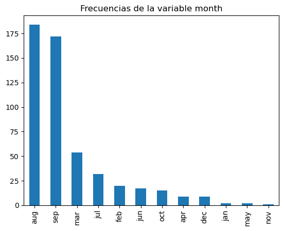

```python
# dibujamos
plot = datos['month'].value_counts().plot(kind='bar', title='Frecuencias de la variable month')
```

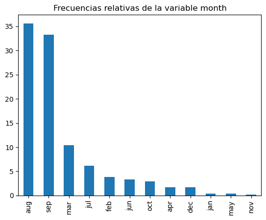

```python
# dibujamos
plot = (100 * datos['month'].value_counts() / len(datos['month'])).plot(
kind='bar', title='Frecuencias relativas de la variable month')
```

```python
#Tabla de frecuencia de la variable month
print("Tabla de frecuencias de la variable day")
pd.value_counts(datos['day'])
```

```
Tabla de frecuencias de la variable day
```

```
sun    95
fri    85
sat    84
mon    74
tue    64
thu    61
wed    54
Name: day, dtype: int64
```

```python
# Tabla de frecuencia relativa de la variable month
print("Tabla de frecuencias relativas de la variable day")
100 * datos['day'].value_counts() / len(datos['day'])
```

```
Tabla de frecuencias relativas de la variable day
```

```
sun    18.375242
fri    16.441006
sat    16.247582
mon    14.313346
tue    12.379110
thu    11.798839
wed    10.444874
Name: day, dtype: float64
```

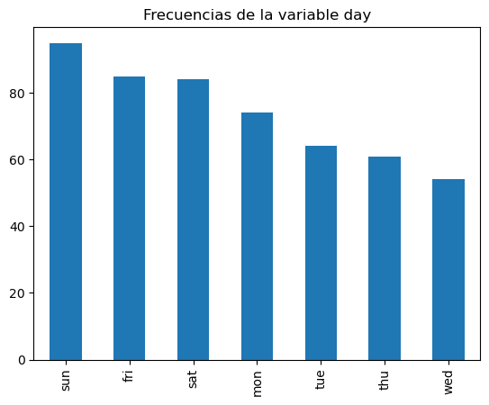

```python
# dibujamos
plot = datos['day'].value_counts().plot(kind='bar', title='Frecuencias de la variable day')
```

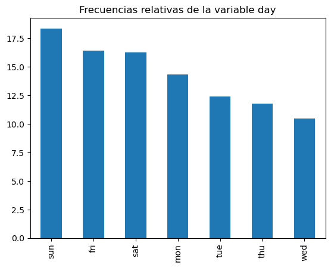

```python
# dibujamos
plot = (100 * datos['day'].value_counts() / len(datos['day'])).plot(
kind='bar', title='Frecuencias relativas de la variable day')
```

**Análisis:** Con las dos variables categorías nos damos cuenta de que los meses de agosto y septiembre son cuando más incendios se han provocado, viendo un descenso bastante considerable el resto de los meses. Respecto a los días de la semana, los fin de semana (del viernes al domingo) son los que mas datos alberga, no obstante el resto de días de la semana también tienen unos datos mas o menos equilibrados, al contrario que pasaba con los meses.

## 2.1.2 Variables numéricas

```python
#Obtenemos solo los datos numericos
datos_numericos =datos.iloc[:,4:13]
datos_numericos.sample(10)
```

|  | FFMC | DMC | DC | ISI | temp | RH | wind | rain | area |
| --- | --- | --- | --- | --- | --- | --- | --- | --- | --- |
| 395 | 85.0 | 9.0 | 56.9 | 3.5 | 10.1 | 62 | 1.8 | 0.0 | 51.78 |
| 451 | 90.5 | 196.8 | 649.9 | 16.3 | 11.8 | 88 | 4.9 | 0.0 | 9.71 |
| 121 | 91.5 | 145.4 | 608.2 | 10.7 | 17.1 | 43 | 5.4 | 0.0 | 0.00 |
| 0 | 86.2 | 26.2 | 94.3 | 5.1 | 8.2 | 51 | 6.7 | 0.0 | 0.00 |
| 465 | 79.5 | 3.6 | 15.3 | 1.8 | 4.6 | 59 | 0.9 | 0.0 | 6.84 |
| 289 | 91.6 | 104.2 | 474.9 | 9.0 | 24.3 | 30 | 1.8 | 0.0 | 0.00 |
| 197 | 92.9 | 137.0 | 706.4 | 9.2 | 21.5 | 15 | 0.9 | 0.0 | 11.06 |
| 112 | 89.7 | 90.0 | 704.4 | 4.8 | 22.8 | 39 | 3.6 | 0.0 | 0.00 |
| 326 | 92.2 | 102.3 | 751.5 | 8.4 | 24.1 | 27 | 3.1 | 0.0 | 0.00 |
| 513 | 81.6 | 56.7 | 665.6 | 1.9 | 21.9 | 71 | 5.8 | 0.0 | 54.29 |

```python
#Estadisticas básicas
print("Estadísticos descriptivos básicos:")
datos_numericos.describe()
```

```
Estadísticos descriptivos básicos:
```

|  | FFMC | DMC | DC | ISI | temp | RH | wind | rain | area |
| --- | --- | --- | --- | --- | --- | --- | --- | --- | --- |
| count | 517.000000 | 517.000000 | 517.000000 | 517.000000 | 517.000000 | 517.000000 | 517.000000 | 517.000000 | 517.000000 |
| mean | 90.644681 | 110.872340 | 547.940039 | 9.021663 | 18.889168 | 44.288201 | 4.017602 | 0.021663 | 12.847292 |
| std | 5.520111 | 64.046482 | 248.066192 | 4.559477 | 5.806625 | 16.317469 | 1.791653 | 0.295959 | 63.655818 |
| min | 18.700000 | 1.100000 | 7.900000 | 0.000000 | 2.200000 | 15.000000 | 0.400000 | 0.000000 | 0.000000 |
| 25% | 90.200000 | 68.600000 | 437.700000 | 6.500000 | 15.500000 | 33.000000 | 2.700000 | 0.000000 | 0.000000 |
| 50% | 91.600000 | 108.300000 | 664.200000 | 8.400000 | 19.300000 | 42.000000 | 4.000000 | 0.000000 | 0.520000 |
| 75% | 92.900000 | 142.400000 | 713.900000 | 10.800000 | 22.800000 | 53.000000 | 4.900000 | 0.000000 | 6.570000 |
| max | 96.200000 | 291.300000 | 860.600000 | 56.100000 | 33.300000 | 100.000000 | 9.400000 | 6.400000 | 1090.840000 |

```python
#Otras Estadisticas
print("Otros estadísticos -> Mediana")
datos_numericos.median()
```

```
Otros estadísticos -> Mediana
```

```
FFMC     91.60
DMC     108.30
DC      664.20
ISI       8.40
temp     19.30
RH       42.00
wind      4.00
rain      0.00
area      0.52
dtype: float64
```

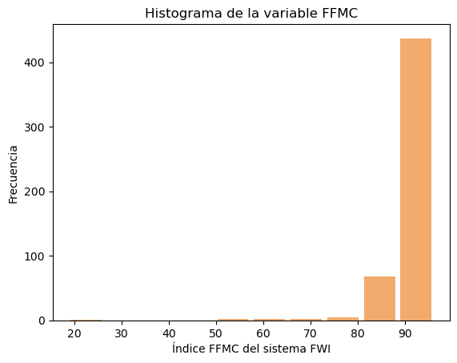

```python
# creamos el histograma
plt.hist(x=datos_numericos.FFMC, color='#F2AB6D', rwidth=0.85)

# configuramos
plt.xlabel('Índice FFMC del sistema FWI')
plt.ylabel('Frecuencia')
plt.title('Histograma de la variable FFMC')

# dibujamos
plt.show()
```

**Análisis:** Como ya se veía en las estadísticas, la media de la variable FFMC estaba muy cerca del límite superior (90.644681), y como se reafirma a nivel visual en el histograma, la distribución esta sesgada a la derecha.

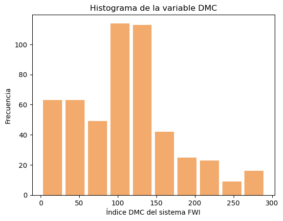

```python
# creamos el histograma
plt.hist(x=datos_numericos.DMC, color='#F2AB6D', rwidth=0.85)

# configuramos
plt.xlabel('Índice DMC del sistema FWI')
plt.ylabel('Frecuencia')
plt.title('Histograma de la variable DMC')

# dibujamos
plt.show()
```

**Análisis:** La variable DMC como se indica en las estadísticas, tiene una media que esta en la mitad inferior del conjunto de valores que puede tomar esta variable, no obstante al contrario que la anterior, DMC tiene una distribución “normal” a un nivel visual, destacando dos valores entre 80 y 150 que tienen notablemente muchos mas valores que el resto.

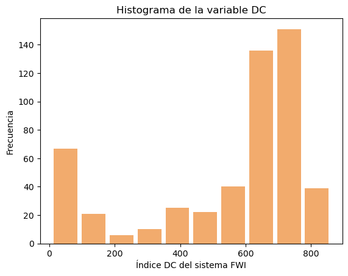

```python
# creamos el histograma
plt.hist(x=datos_numericos.DC, color='#F2AB6D', rwidth=0.85)

# configuramos
plt.xlabel('Índice DC del sistema FWI')
plt.ylabel('Frecuencia')
plt.title('Histograma de la variable DC')

# dibujamos
plt.show()
```

**Análisis:** La variable DC tiene valores extremos, en el sentido de que el mayor numero de registros esta en un valor bajo o en un valor tocando al máximo. No obstante, se observa que la distribución no es normal, y que tiene un sesgo notorio a la derecha, igual que ocurría con la variable FFMC.

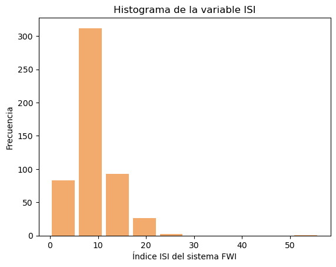

```python
# creamos el histograma
plt.hist(x=datos_numericos.ISI, color='#F2AB6D', rwidth=0.85)

# configuramos
plt.xlabel('Índice ISI del sistema FWI')
plt.ylabel('Frecuencia')
plt.title('Histograma de la variable ISI')

# dibujamos
plt.show()
```

**Análisis:** La variable ISI, al contrario que sus antecesoras, esta segada a la izquierda, haciendo que la media en su caso este cerca al limite inferior (9.021663).

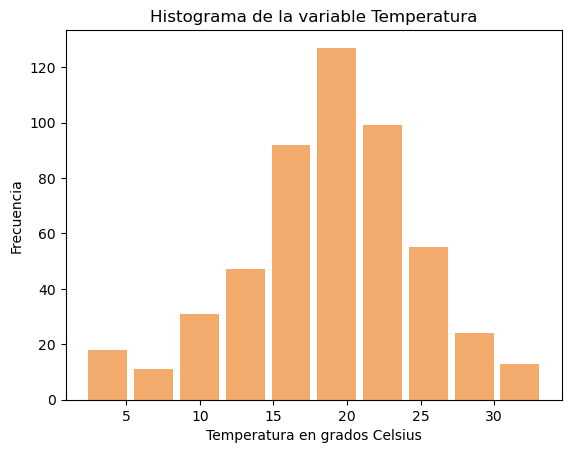

```python
# creamos el histograma
plt.hist(x=datos_numericos.temp, color='#F2AB6D', rwidth=0.85)

# configuramos
plt.xlabel('Temperatura en grados Celsius')
plt.ylabel('Frecuencia')
plt.title('Histograma de la variable Temperatura')

# dibujamos
plt.show()
```

**Análisis:** La temperatura tiene una distribución normal, teniendo la media en 18,89º Celsius, lo que es una temperatura normal para la zona en la que se ha llevado el registro.

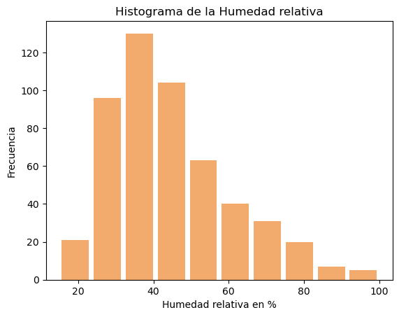

```python
# creamos el histograma
plt.hist(x=datos_numericos.RH, color='#F2AB6D', rwidth=0.85)

# configuramos
plt.xlabel('Humedad relativa en %')
plt.ylabel('Frecuencia')
plt.title('Histograma de la Humedad relativa')

# dibujamos
plt.show()
```

**Análisis:** La Humedad relativa esta segada hacia la izquierda, ya que como se muestra a nivel visual y con las estadísticas tiene una humedad relativa en torno al 30-40%. No obstante, se debería investigar más sobre la humedad media de la zona para contrastar los datos.

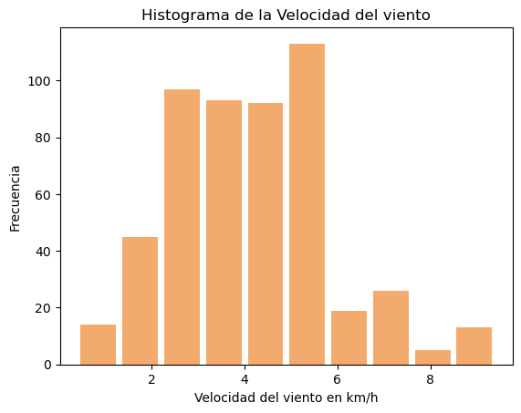

```python
# creamos el histograma
plt.hist(x=datos_numericos.wind, color='#F2AB6D', rwidth=0.85)

# configuramos
plt.xlabel('Velocidad del viento en km/h')
plt.ylabel('Frecuencia')
plt.title('Histograma de la Velocidad del viento')

# dibujamos
plt.show()
```

**Análisis:** La velocidad del viento tiene una distribución normal siendo la media de esta 4.017602 km/h.

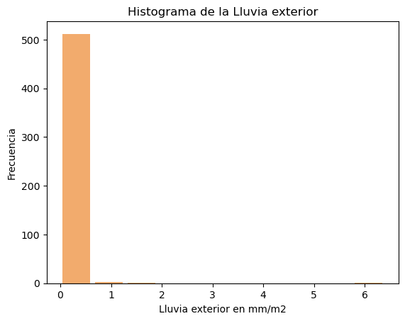

```python
# creamos el histograma
plt.hist(x=datos_numericos.rain, color='#F2AB6D', rwidth=0.85)

# configuramos
plt.xlabel('Lluvia exterior en mm/m2')
plt.ylabel('Frecuencia')
plt.title('Histograma de la Lluvia exterior')

# dibujamos
plt.show()
```

**Análisis:** El histograma y las estadísticas de la lluvia nos da el dato de que en la zona llueve poco, por lo que este dato esta muy cerca del 0, siendo su media 0.021663 mm/m2. Al tener un dato máximo (6,4) bastante alejado de la media y sin apenas datos hace pensar que ese dato ha sido un error a la hora de añadir los datos.

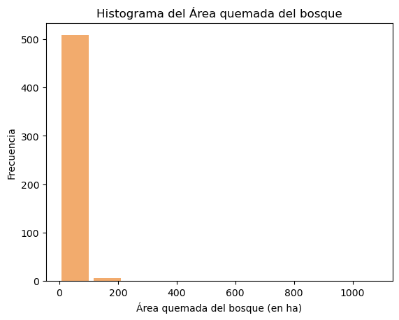

```python
# creamos el histograma
plt.hist(x=datos_numericos.area, color='#F2AB6D', rwidth=0.85)

# configuramos
plt.xlabel('Área quemada del bosque (en ha)')
plt.ylabel('Frecuencia')
plt.title('Histograma del Área quemada del bosque')

# dibujamos
plt.show()
```

**Análisis:** El area quemada del bosque de media por incendio suele ser de 12,85 hectareas. Al ver que tenemos en valor máximo en las estadísticas en 1090,84 hectareas nos hace pensar de que este dato puede ser un error a la hora de meter el dato.

## 2.1.3 Variables geoespaciales

```python
#Obtenemos solo los datos geoespaciales
datos_geo =datos.iloc[:,0:2]
datos_geo.sample(3)
```

|  | X | Y |
| --- | --- | --- |
| 6 | 8 | 6 |
| 225 | 4 | 4 |
| 201 | 6 | 5 |

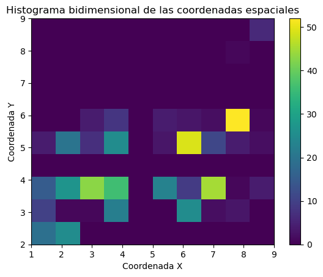

```python
# creamos el histograma
plt.hist2d(datos_geo.X, datos_geo.Y);

# configuramos
plt.colorbar();
plt.title('Histograma bidimensional de las coordenadas espaciales');
plt.xlabel('Coordenada X');
plt.ylabel('Coordenada Y');

# dibujamos
plt.show()
```

## 2.2 Análisis exploratorio de los datos

En este apartado exploraremos la relación de los atributos descriptivos con la variable objetivo.  
Nota: trataremos de forma diferente los atributos categóricos de los numéricos

**Ejercicio:** para cada variable categórica, mostrad un gráfico donde superpondréis para cada categoría un histograma de los valores de la variable objetivo. Añadid una leyenda para saber a qué clase corresponde cada histograma La finalidad es observar como se distribuye el valor de la variable objetivo en función de los valores de las categorías de cada variable categórica. De esta forma, identificaremos de manera visual y rápida si este atributo categórico está relacionado o no con diferentes valores de la respuesta.

Sugerencia: podéis usar la función "hist" de la librería "matplotlib", así como su parámetro "alpha" (transparencia) para que se aprecien los histogramas superpuestos.

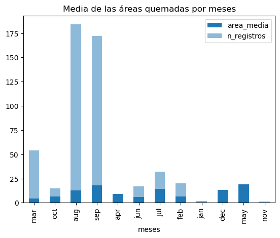

```python
valores_month = datos['month'].unique().tolist()
valores_month

df = pd.DataFrame()
df['meses'] = None
df['area_media'] = None
df['n_registros'] = None

for valor in valores_month:

    valores = datos[datos.month.str.contains(valor)]
    media = valores['area'].mean()
    df = pd.concat([df, pd.DataFrame.from_records([{ 'meses': valor, 'area_media': media, 'n_registros' : valores.shape[0] }])])


dfi = df.set_index('meses')


plot = dfi['area_media'].plot(kind='bar', title='Media de las áreas quemadas por meses')
plot = dfi['n_registros'].plot(kind='bar', title='Media de las áreas quemadas por meses',alpha = 0.5 )

plt.legend(loc='upper right')
plt.show()
```

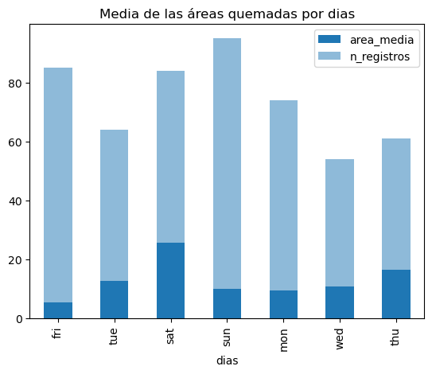

```python
valores_day = datos['day'].unique().tolist()
valores_day

df = pd.DataFrame()
df['dias'] = None
df['area_media'] = None
df['n_registros'] = None

for valor in valores_day:

    valores = datos[datos.day.str.contains(valor)]
    media = valores['area'].mean()
    df = pd.concat([df, pd.DataFrame.from_records([{ 'dias': valor, 'area_media': media, 'n_registros' : valores.shape[0] }])])


dfi = df.set_index('dias')


plot = dfi['area_media'].plot(kind='bar', title='Media de las áreas quemadas por dias')
plot = dfi['n_registros'].plot(kind='bar', title='Media de las áreas quemadas por dias',alpha = 0.5 )

plt.legend(loc='upper right')
plt.show()
```

**Análisis:** Ocurre lo mismo con los días de la semana, como se ha visto anteriormente los fin de semana (del viernes al domingo) son los que más datos alberga y en proporción de area quemadas es solo el sábado cuando mas áreas de media ha sido quemada, siguiéndole el jueves.

**Análisis:** mirando los histogramas, ¿te parece que los atributos categóricos tendrán algún peso a la hora de predecir la variable objetivo? ¿Porqué?

**Respuesta:** Si, como se observa en los histogramas, no en todos los meses o días se queman de media más áreas. Estos datos nos pueden dar información útil respecto hacia donde ajustar las predicciones, ya que nos puede proporcionar un sistema predictivo por meses y días de las semanas.

**Ejercicio:** para cada categoría de las variables categóricas calculad los valores de media y desviación estandard de la variable objetivo. La finalidad de este ejercicio es verificar numéricamente las diferencias identificadas anteriormente de forma visual.

Sugerencia: podéis usar las funciones "mean" y "std" de la librería "numpy".

```python
for valor in valores_day:

    valores = datos[datos.day.str.contains(valor)]
    areas = valores['area']
    print("Para el día:", valor, "la media de la variable area es:", areas.mean(), "y su desviación estandard es:", np.std(areas))
```

```
Para el día: fri la media de la variable area es: 5.261647058823529 y su desviación estandard es: 9.953014068708189
Para el día: tue la media de la variable area es: 12.62171875 y su desviación estandard es: 33.30490910486617
Para el día: sat la media de la variable area es: 25.534047619047627 y su desviación estandard es: 121.96630260736792
Para el día: sun la media de la variable area es: 10.104526315789473 y su desviación estandard es: 25.93842639257424
Para el día: mon la media de la variable area es: 9.547702702702704 y su desviación estandard es: 33.4750609287255
Para el día: wed la media de la variable area es: 10.714814814814815 y su desviación estandard es: 30.004178149837536
Para el día: thu la media de la variable area es: 16.345901639344262 y su desviación estandard es: 94.56625614475928
```

**Análisis:** Con los datos numéricos, se corrobora lo que visualmente se ha observado sobre el area quemada de media en los días de la semana.

```python
for valor in valores_month:

    valores = datos[datos.month.str.contains(valor)]
    areas = valores['area']
    print("Para el mes:", valor, "la media de la variable area es:", areas.mean(), "y su desviación estandard es:", np.std(areas))
```

```
Para el mes: mar la media de la variable area es: 4.356666666666667 y su desviación estandard es: 9.055080832819158
Para el mes: oct la media de la variable area es: 6.638 y su desviación estandard es: 13.234995630272543
Para el mes: aug la media de la variable area es: 12.489076086956521 y su desviación estandard es: 60.199917437422435
Para el mes: sep la media de la variable area es: 17.942616279069753 y su desviación estandard es: 87.39301223072546
Para el mes: apr la media de la variable area es: 8.891111111111112 y su desviación estandard es: 18.789328203024922
Para el mes: jun la media de la variable area es: 5.841176470588234 y su desviación estandard es: 16.38080256683304
Para el mes: jul la media de la variable area es: 14.3696875 y su desviación estandard es: 50.04847247196805
Para el mes: feb la media de la variable area es: 6.275 y su desviación estandard es: 12.029991064003333
Para el mes: jan la media de la variable area es: 0.0 y su desviación estandard es: 0.0
Para el mes: dec la media de la variable area es: 13.33 y su desviación estandard es: 6.232671979175545
Para el mes: may la media de la variable area es: 19.24 y su desviación estandard es: 19.24
Para el mes: nov la media de la variable area es: 0.0 y su desviación estandard es: 0.0
```

**Análisis:** Con los datos numéricos, se corrobora lo que visualmente se ha observado sobre el area quemada de media en los meses del año.

**Ejercicio:** calculad y mostrad la correlación entre todos los atributos numéricos (incluyendo los geoespaciales) y la respuesta.

```python
#La correlacion de los atributos y la variable objetivo
corr = datos.corr()
corr[-1:]
```

|  | X | Y | FFMC | DMC | DC | ISI | temp | RH | wind | rain | area |
| --- | --- | --- | --- | --- | --- | --- | --- | --- | --- | --- | --- |
| area | 0.063385 | 0.044873 | 0.040122 | 0.072994 | 0.049383 | 0.008258 | 0.097844 | -0.075519 | 0.012317 | -0.007366 | 1.0 |

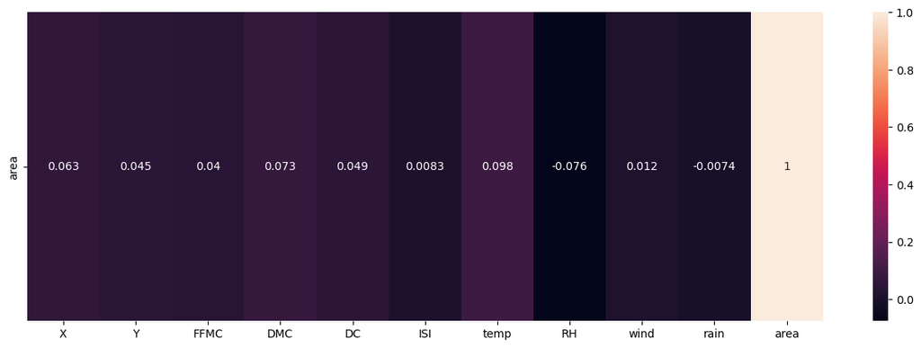

```python
# También puede verse gráficamente a través de un mapa de calor la correlaciones de los atributos y la variable objetivo
corr = datos.corr()[-1:]
plt.figure(figsize=(16,5))
sns.heatmap(corr, annot=True)
plt.show()
plt.clf()
```

**Análisis:** Como se puede ver en el mapa de calor, y en los resultados numéricos las variables numéricas respecto a la variable objetivo tienen una correlación muy baja.

**Ejercicio:** representad gráficamente las relaciones entre todas las parejas de las variables numéricas del conjunto de datos (incluyendo las geoespaciales). La finalidad de este ejercicio es poder observar y analizar las correlaciones entre las variables de manera gráfica.

Sugerencia: podéis usar la función "pairplot" de la librería 'seaborn'.

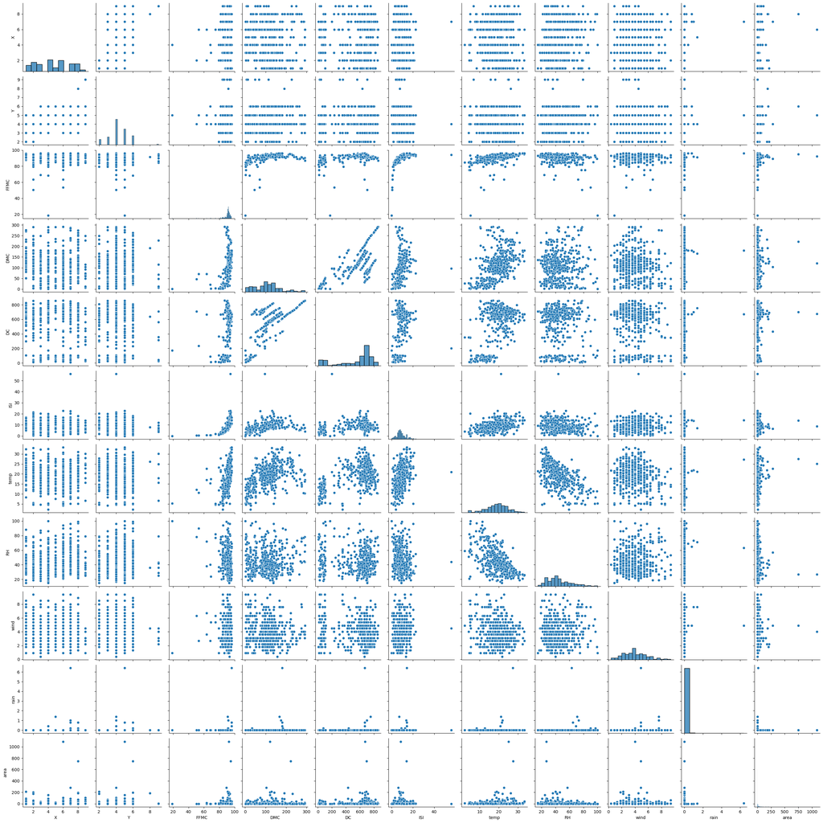

```python
sns.pairplot(datos)
```

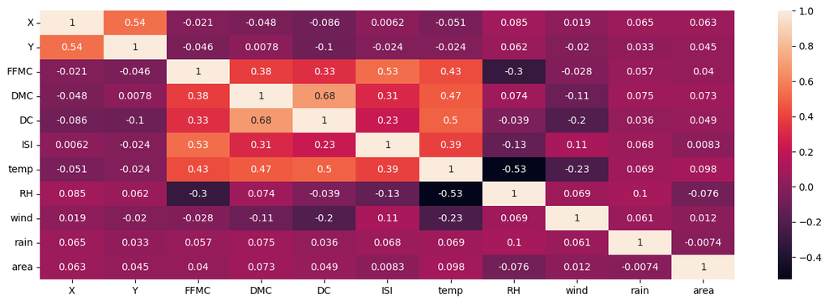

```python
# También puede verse gráficamente a través de un mapa de calor la correlaciones de los atributos
corr = datos.corr()
plt.figure(figsize=(16,5))
sns.heatmap(corr, annot=True)
plt.show()
plt.clf()
```

**Análisis:** Aunque visualmente se pueden observar las relaciones entre variables, para un análisis mas concreto se ha decidido mostrar también con un mapa de calor las correlaciones.

**Ejercicio:** identificad los 2 atributos que tienen una correlación más fuerte con la respuesta y los 3 con una correlación más débil (coeficiente de correlación mayor o menor en valor absoluto). Para observar y analizar las correlaciones gráficamente, representad, para cada uno de los 5 atributos identificados, un scatter plot con el atributo en el eje x y la respuesta en el eje y. Además, en cada gráfico añadid la representación de una regresión lineal que fite los puntos.

Sugerencia: podéis usar la función "regplot" de la librería 'seaborn'.

[figure not shown]

```python
# Variables más correlacionadas
selected_vars = ['temp', 'DMC']

fig, axs = plt.subplots(nrows=1, ncols=2, figsize=(10,5))
index = 0
titulos=[["1º Más correlacionada","green"], ["2º Más correlacionada","green"]]

for i, k in enumerate(selected_vars):
    sns.regplot(y=datos['area'], x=datos[k], ax=axs[i], color=titulos[i][1]).set(title=titulos[i][0])
```

[figure not shown]

```python
# Variables menos correlacionadas
selected_vars = ['RH', 'rain', 'ISI']

fig, axs = plt.subplots(nrows=1, ncols=3, figsize=(15,5))
index = 0
extra=[["1º Menos correlacionada","red"], ["2º Menos correlacionada","red"],["3º Menos correlacionada","red"]]

for i, k in enumerate(selected_vars):
    sns.regplot(y=datos['area'], x=datos[k], ax=axs[i], color=extra[i][1]).set(title=extra[i][0])
```

**Análisis:** observando los gráficos, comentad brevemente si conseguís ver las altas o bajas correlaciones que habíais identificado numéricamente.

# 3. Preprocesado de los datos (3 puntos)

Una vez analizados los atributos descriptivos, es el momento de prepararlos para que nos sean útiles de cara a predecir valores. En este apartado:

Transformaremos las variables categóricas en varias variables binarias, una para cada categoría.

Estandarizaremos los valores de los atributos descriptivos para que sus escalas no sean muy diferentes.

Separaremos el conjunto de datos original en dos subconjuntos: entrenamiento y test.

**Ejercicio:** elimina los atributos categóricos del conjunto de datos y en su lugar introduce la transformación de dichos atributos a tantas variables binarias como categorías tengan.

Sugerencia: utilizad la función "get_dummies" de "pandas".

```python
dummies = pd.get_dummies(datos[["month", "day"]], drop_first=True)
dummies.head()
```

|  | month_aug | month_dec | month_feb | month_jan | month_jul | month_jun | month_mar | month_may | month_nov | month_oct | month_sep | day_mon | day_sat | day_sun | day_thu | day_tue | day_wed |
| --- | --- | --- | --- | --- | --- | --- | --- | --- | --- | --- | --- | --- | --- | --- | --- | --- | --- |
| 0 | 0 | 0 | 0 | 0 | 0 | 0 | 1 | 0 | 0 | 0 | 0 | 0 | 0 | 0 | 0 | 0 | 0 |
| 1 | 0 | 0 | 0 | 0 | 0 | 0 | 0 | 0 | 0 | 1 | 0 | 0 | 0 | 0 | 0 | 1 | 0 |
| 2 | 0 | 0 | 0 | 0 | 0 | 0 | 0 | 0 | 0 | 1 | 0 | 0 | 1 | 0 | 0 | 0 | 0 |
| 3 | 0 | 0 | 0 | 0 | 0 | 0 | 1 | 0 | 0 | 0 | 0 | 0 | 0 | 0 | 0 | 0 | 0 |
| 4 | 0 | 0 | 0 | 0 | 0 | 0 | 1 | 0 | 0 | 0 | 0 | 0 | 0 | 1 | 0 | 0 | 0 |

```python
datos_preprocesados = datos

# Añadimos las variables binarias al DataFrame
datos_preprocesados = pd.concat([datos_preprocesados, dummies], axis = 1)

# Eliminamos la vairables originales race
datos_preprocesados = datos_preprocesados.drop(columns=["month", "day"])

# Muestra de 10 datos
datos_preprocesados.head()
```

|  | X | Y | FFMC | DMC | DC | ISI | temp | RH | wind | rain | area | month_aug | month_dec | month_feb | month_jan | month_jul | month_jun | month_mar | month_may | month_nov | month_oct | month_sep | day_mon | day_sat | day_sun | day_thu | day_tue | day_wed |
| --- | --- | --- | --- | --- | --- | --- | --- | --- | --- | --- | --- | --- | --- | --- | --- | --- | --- | --- | --- | --- | --- | --- | --- | --- | --- | --- | --- | --- |
| 0 | 7 | 5 | 86.2 | 26.2 | 94.3 | 5.1 | 8.2 | 51 | 6.7 | 0.0 | 0.0 | 0 | 0 | 0 | 0 | 0 | 0 | 1 | 0 | 0 | 0 | 0 | 0 | 0 | 0 | 0 | 0 | 0 |
| 1 | 7 | 4 | 90.6 | 35.4 | 669.1 | 6.7 | 18.0 | 33 | 0.9 | 0.0 | 0.0 | 0 | 0 | 0 | 0 | 0 | 0 | 0 | 0 | 0 | 1 | 0 | 0 | 0 | 0 | 0 | 1 | 0 |
| 2 | 7 | 4 | 90.6 | 43.7 | 686.9 | 6.7 | 14.6 | 33 | 1.3 | 0.0 | 0.0 | 0 | 0 | 0 | 0 | 0 | 0 | 0 | 0 | 0 | 1 | 0 | 0 | 1 | 0 | 0 | 0 | 0 |
| 3 | 8 | 6 | 91.7 | 33.3 | 77.5 | 9.0 | 8.3 | 97 | 4.0 | 0.2 | 0.0 | 0 | 0 | 0 | 0 | 0 | 0 | 1 | 0 | 0 | 0 | 0 | 0 | 0 | 0 | 0 | 0 | 0 |
| 4 | 8 | 6 | 89.3 | 51.3 | 102.2 | 9.6 | 11.4 | 99 | 1.8 | 0.0 | 0.0 | 0 | 0 | 0 | 0 | 0 | 0 | 1 | 0 | 0 | 0 | 0 | 0 | 0 | 1 | 0 | 0 | 0 |

**Ejercicio:** estandariza todos los atributos descriptivos.

Sugerencia: utilizad "StandardScaler" de "preprocessing".

```python
# Código basado en el siguiente: https://github.com/SasaIA/StandardScaler/blob/master/StandardScaler.ipynb

class StandardScaler2():
    def __init__(self):
        self.params_ = {}

    def fit(self, X):
        self.mean_ = np.mean(X, axis=0)
        self.scale_ = np.std(X - self.mean_, axis=0)
        self.params_.update({"mean": self.mean_, "scale": self.scale_})
        return self

    def transform(self, X):
        return (X - self.mean_) / self.scale_

    def fit_transform(self, X):
        return self.fit(X).transform(X)

scaler = StandardScaler2()
datos_preprocesados = scaler.fit_transform(datos_preprocesados)
datos_preprocesados.head()
```

|  | X | Y | FFMC | DMC | DC | ISI | temp | RH | wind | rain | area | month_aug | month_dec | month_feb | month_jan | month_jul | month_jun | month_mar | month_may | month_nov | month_oct | month_sep | day_mon | day_sat | day_sun | day_thu | day_tue | day_wed |
| --- | --- | --- | --- | --- | --- | --- | --- | --- | --- | --- | --- | --- | --- | --- | --- | --- | --- | --- | --- | --- | --- | --- | --- | --- | --- | --- | --- | --- |
| 0 | 1.008313 | 0.569860 | -0.805959 | -1.323326 | -1.830477 | -0.860946 | -1.842640 | 0.411724 | 1.498614 | -0.073268 | -0.20202 | -0.743339 | -0.133103 | -0.200603 | -0.062318 | -0.256865 | -0.184391 | 2.928152 | -0.062318 | -0.044023 | -0.172860 | -0.706081 | -0.408709 | -0.440449 | -0.474467 | -0.365748 | -0.375873 | -0.341512 |
| 1 | 1.008313 | -0.244001 | -0.008102 | -1.179541 | 0.488891 | -0.509688 | -0.153278 | -0.692456 | -1.741756 | -0.073268 | -0.20202 | -0.743339 | -0.133103 | -0.200603 | -0.062318 | -0.256865 | -0.184391 | -0.341512 | -0.062318 | -0.044023 | 5.785038 | -0.706081 | -0.408709 | -0.440449 | -0.474467 | -0.365748 | 2.660475 | -0.341512 |
| 2 | 1.008313 | -0.244001 | -0.008102 | -1.049822 | 0.560715 | -0.509688 | -0.739383 | -0.692456 | -1.518282 | -0.073268 | -0.20202 | -0.743339 | -0.133103 | -0.200603 | -0.062318 | -0.256865 | -0.184391 | -0.341512 | -0.062318 | -0.044023 | 5.785038 | -0.706081 | -0.408709 | 2.270410 | -0.474467 | -0.365748 | -0.375873 | -0.341512 |
| 3 | 1.440925 | 1.383722 | 0.191362 | -1.212361 | -1.898266 | -0.004756 | -1.825402 | 3.233519 | -0.009834 | 0.603155 | -0.20202 | -0.743339 | -0.133103 | -0.200603 | -0.062318 | -0.256865 | -0.184391 | 2.928152 | -0.062318 | -0.044023 | -0.172860 | -0.706081 | -0.408709 | -0.440449 | -0.474467 | -0.365748 | -0.375873 | -0.341512 |
| 4 | 1.440925 | 1.383722 | -0.243833 | -0.931043 | -1.798600 | 0.126966 | -1.291012 | 3.356206 | -1.238940 | -0.073268 | -0.20202 | -0.743339 | -0.133103 | -0.200603 | -0.062318 | -0.256865 | -0.184391 | 2.928152 | -0.062318 | -0.044023 | -0.172860 | -0.706081 | -0.408709 | -0.440449 | 2.107630 | -0.365748 | -0.375873 | -0.341512 |

**Ejercicio:** separa los atributos descriptivos y la variable objetivo en los subconjuntos de entrenamiento y test.

Sugerencia: para separar entre train y test podéis usar "train_test_split" de sklearn.

```python
# Se define el dataset de train y test con los datos originales
X = datos_preprocesados
y = datos_preprocesados['area']
X = X.drop(columns=['area'])
print(f"Dimensiones de X (vartiables):{X.shape}\nDimensiones de y (Variable Objetivo): {y.shape}")
```

```
Dimensiones de X (vartiables):(517, 27)
Dimensiones de y (Variable Objetivo): (517,)
```

```python
# Proporción de separación de datasets de train y test
train_perc = 0.7

# Separación de dataset de train y test, en variables de decisión y de clase
X_train, X_test, y_train, y_test = train_test_split(X, y, test_size=(1-train_perc))
print(f"Dimensiones de Train\n--------------------\n\tX (vartiables):{X_train.shape}\n\ty (Variable Objetivo): {y_train.shape}\n")
print(f"Dimensiones de Test\n--------------------\n\tX (vartiables):{X_test.shape}\n\ty (Variable Objetivo): {y_test.shape}")
```

```
Dimensiones de Train
--------------------
	X (vartiables):(361, 27)
	y (Variable Objetivo): (361,)

Dimensiones de Test
--------------------
	X (vartiables):(156, 27)
	y (Variable Objetivo): (156,)
```

**Análisis:** explica si la decisión de transformar el conjunto de datos (variables categóricas y estandarización) antes de realizar la separación del conjunto de datos en los subconjuntos de entrenamiento y test es una buena idea.

**Respuesta:** Al transformar todos los datos, ha sido una idea buena hacerlo antes de dividir los datos, ya que todos los datos se han transformado por la misma regla y no de manera distinta. Es decir, ahora mismo es como una copia del conjunto original, pero en que se ha realizado una transformación para todos los datos por igual antes de dividirlo, por ese motivo es mejor hacerlo antes que después, así se queda constancia de que se ha hecho de la misma forma el conjunto de test y de entrenamiento.

# 4. Reducción de la dimensionalidad (2 puntos)

Con el propósito de comprobar visualmente la distribución de la variable objetivo teniendo en cuenta todos los atributos descriptivos a la vez, vamos a reducir la dimensionalidad del problema a solamente dos atributos que serán la proyección de los atributos descriptivos originales.

**Ejercicio:**

- Aplicad el método de reducción de la dimensionalidad Principal Component Analysis (PCA) para reducir a 2 dimensiones el dataset original que contiene todos los atributos.
- Generad un gráfico con el resultado del PCA en el que se muestre, en función de los valores de las dos componentes en los ejes x e y, el valor de la variable objetivo usando la escala de colores. El objetivo es visualizar la variación de la variable objetivo en función de los valores de las componentes principales generadas.

NOTA: cuidado, no incluyáis la variable objetivo en la reducción de dimensionalidad. Queremos explicar la variable objetivo en función del resto de variables reducidas a dos dimensiones.

Sugerencia: no es necesario que programéis el algoritmo de PCA, podéis usar la implementación disponible en la librería de "scikit-learn".  
Sugerencia: para el gráfico, podéis usar el scatter plot de matplotlib con el parámetro "c", que indica el color de los puntos, igual a la variable objetivo.  
Sugerencia: utilizad el parámetro "norm=matplotlib.colors.LogNorm()" dentro del "scatter" para mostrar de forma logarítmica el área quemada de bosque.

```python
# Se separan las variables de decisión de la variable de clase en X e y respectivamente
X = datos_preprocesados
y = datos_preprocesados['area']
X = X.drop(columns=['area'])

# Se crea el modelo y se aplica
model_pca = PCA(n_components=2, random_state=seed)
PCA_salida = model_pca.fit_transform(X)

# Se muestra los resultados
print(f"Dimensiones luego de aplicar PCA: {np.shape(PCA_salida)}")
print(f"Ratio de varianza 1ª componente: {model_pca.explained_variance_ratio_[0]}")
print(f"Ratio de varianza 2ª componente: {model_pca.explained_variance_ratio_[1]}")
```

```
Dimensiones luego de aplicar PCA: (517, 2)
Ratio de varianza 1ª componente: 0.13917182031026107
Ratio de varianza 2ª componente: 0.07224962641608126
```

[output not shown]

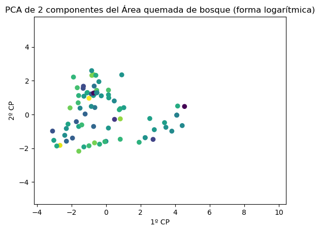

```python
plt.scatter(x=PCA_salida[:,0], y=PCA_salida[:,1], c=y, norm=matplotlib.colors.LogNorm())
plt.gca().update(dict(title="PCA de 2 componentes del Área quemada de bosque (forma logarítmica)", xlabel='1º CP', ylabel='2º CP'))
```

**Ejercicio:**

- Repetid la reducción de dimensionalidad, pero en este caso usando TSNE. Podéis encontrar más información sobre este algoritmo en el link: https://distill.pub/2016/misread-tsne/
- Al igual que antes, generad un gráfico con el resultado del TSNE en el que se muestre, en función de los valores de las 2 nuevas dimensiones en los ejes x e y, el valor de la variable objetivo usando una escala de colores.

Sugerencia: no es necesario que programéis el algoritmo TSNE, podéis usar la implementación disponible en la librería de "scikit-learn".  
Sugerencia: a parte de especificar el número de componentes, probad a usar los parámetros "learning_rate" y "perplexity".  
Sugerencia: para el gráfico, podéis usar el scatter plot de matplotlib con el parámetro "c", que indica el color de los puntos, igual a la variable objetivo.  
Sugerencia: utilizad el parámetro "norm=matplotlib.colors.LogNorm()" dentro del "scatter" para mostrar de forma logarítmica el área quemada de bosque.

[output not shown]

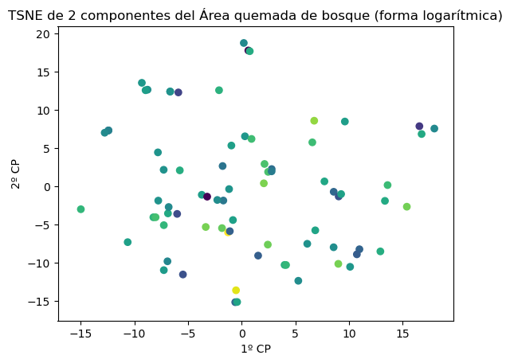

```python
# Se separan las variables de decisión de la variable de clase en X e y respectivamente
X = datos_preprocesados
y = datos_preprocesados['area']
X = X.drop(columns=['area'])

# Se crea el modelo y se aplica
model_tsne = TSNE(init='random', n_components=2, perplexity=60, learning_rate=200)
TSNE_Salida = model_tsne.fit_transform(X)

plt.scatter(x=TSNE_Salida[:,0], y=TSNE_Salida[:,1], c=y, norm=matplotlib.colors.LogNorm())
plt.gca().update(dict(title="TSNE de 2 componentes del Área quemada de bosque (forma logarítmica)", xlabel='1º CP', ylabel='2º CP'))
```

**Análisis:** observando los dos gráficos, ¿creéis que ha funcionado bien la reducción de dimensionalidad? ¿Os parece que las 2 nuevas dimensiones consiguen explicar la variación de la variable objetivo y visualizar diferenciadamente áreas de indendio grandes o pequeñas? ¿Si utilizásemos las 2 nuevas variables para predecir la variable objetivo, serían buenos los resultados obtenidos? ¿Por qué obtenemos resultados tan diferentes con los dos métodos?

**Respuesta:** A través de PCA y TSNE se logra reducir la dimensionalidad del modelo. Pero con PCA se puede ver “mejor” una separación en dos grupos. Además, se puede observar que la reducción a través de PCA presenta en el scatter una distribución más o menos centrada en el valor 0 de la primera componente, algo que no ocurre con TSNE. A nivel visual no creo que ninguna de las 2 nuevas dimensiones consigan explicar la variación de la variable objetivo y visualizar de una manera diferencia el área de los incendios.Por lo que no serian buenos los resultados obtenidos. Se obtienen resultados distintos porque el procedimiento por el cual se eligen los componentes son distintos. El algoritmo PCA se basa en minimizar distancias, por el contrario en TSNE, se centra en mantener las distancias relativas.

# 5. Entrenamiento y test (1 punto)

En este último ejercicio se trata de aplicar un método de aprendizaje supervisado, concretamente el Random Forest para regresión, con el objetivo de predecir la variable objetivo y evaluar la precisión obtenida con el modelo. Para ello:

- Entrenaremos el modelo con el conjunto de entrenamiento y veremos qué tal se comporta tanto con el subconjunto de entrenamiento como con el de test.
- Analizaremos si el resultado obtenido tiene sentido y veremos si se puede mejorar de alguna forma.

**Ejercicio:** usando el conjunto de datos preprocesado (variables categóricas y estandarización) sin aplicar reducción de la dimensionalidad:

- Definid un modelo Random Forest (fijando n_estimators=100 y random_state=seed).
- Mostrad la precisión del modelo tanto en el subconjunto de entrenamiento como de test.

Sugerencia: para entrenar un modelo random forest podéis usar "RandomForestRegressor" de sklearn.  
Sugerencia: para mostrar la precisión del modelo podéis usar el método "score" del propio modelo.

```python
# Definición del modelo
modelRF = RandomForestRegressor(n_estimators=100, random_state=seed)

#Uso del modelo
modelRF.fit(X_train, y_train.values.ravel())
y_pred = modelRF.predict(X_test)

#Resultados
score_train = modelRF.score(X_train,y_train)
score_Test = modelRF.score(X_test,y_test)

print("Score Train:", score_train)
print("Score Test:", score_Test)
```

```
Score Train: 0.8480798931224084
Score Test: -1.882556016768631
```

**Análisis:** explica por qué la precisión del modelo sobre los valores de entrenamiento y test presentan esos valores.

**Respuesta:** La predicción del conjunto de entrenamiento es tan alta ya que es con ese mismo conjunto con los que se ha entrenado el modelo, no obstante, cuando se intenta predecir el modelo de test, la predicción es muy baja, por lo que no es un modelo bueno para predecir.

**Análisis:** discutid qué técnicas podríais aplicar para mejorar la situación actual del modelo.

**Respuesta:** Entre varias mejoras podría ser la mejor limpieza y preparación de los datos, para no tener muchos registros outliers y así no generar mucha profundidad en las ramas del árbol. Por otro lado, se podría usar la poda y hacer un modelo de predicción hibrido.